# A Look At The Wage Gap

Kaamna Rishi, Lynzley Kolakowski, Locksley Kolakowski, Group E4

2/26/2020

## Section 1. Problem Domain Description

The gender wage gap or pay gap is the average difference in salary for men and women working for certain companies or in certain industries. Due to a history of patriarchal societies globally where it was forbidden for women to attain certain rights and privileges through a social hierarchy, the effect has left us with a contemporary era where women have attained the right to work and make a living but the inequality is rooted within the amount of money women get paid while doing equal or more work than their other gender counterparts. What is *specific* to our report is helping the public understand this gap within the technology industry with variables such as location, companies, and education in comparison with average salary data from around the world. This domain is worth analyzing because **we are living in a generation where conversations on possible solutions to wage inequalities are being initiated, but literal action has yet to be taken within our governments and societies.** Especially in the technological industry, one of the highest paying industries and with the fastest expansion all over the world, equal pay is something that has not been quickly prioritized. In this report, we will explain the urgency that needs to be after the priority of equal pay across genders through understanding the average wages of countries and average wages in the technology industry.

### Subsection 1.1 Analysis Questions

Here we will be describing what questions we will be further exploring through our data wrangling in our future report on the wage gap.

Kaamna:

**What is the difference between net income of an average person in the United States compared to a woman working for a Technology company in the U.S.?**

I believe this question is important to understand the average income of a person regardless of gender in the United States compared to a woman’s income from a company that promises the most diversity and inclusion in their hiring and treatment of employees. This will help prove if Microsoft is an equal opportunity employer and is committed to equal pay amongst all genders.

Lynzley:

**Does the gender wage gap differ between people working both within and outside of the tech industry in the United States?**

I believe this question is important because it will help us understand if the job title correlates to the size of the gender wage gap, and if there are differences in the gender wage gap depending on whether individuals working in or outside of the tech industry. This will help prove if the wage gap is more prevalent in specific industries and if technology companies are really providing equal opportunities to people regardless of gender.

Locksley:

**Does education level affect the average compensation between different genders?**

I believe this question is important because it can help indicate whether different education levels determine pay in the tech industry. This is really important because it can help future students planning on pursuing a career in technology make informed decisions on if making the monetary and time commitment to pursuing higher education will affect their compensation once they enter the industry. Furthermore, it will indicate whether men and women experience inequalities in their education level and compensation, hopefully providing evidence towards the gender pay gap.

## Section 2. Data Description

Here we will be further exloring and explaining our data sets and how we have chosen them, then we will wrangle and display an overview of our summary analysis.

### Reddit Tech Data

#### Question 1 - Non-technichal Description

The Reddit Tech Salary Sheet is a dataset detailing the salary, company, location, gender, and more of people who chose to share their information who work in the tech industry.

#### Question 2 - Where Did the Data Come From?

The dataset was created from a user on Reddit, a social media website where the users stay anonymous. The user made the data set using Google Sheets where anyone with the link could input information. I found the source and a csv to download from this link: https://www.reddit.com/r/sysadmin/comments/d2g4hm/reddit_tech_salary_sheet/, and you can view the dataset here: https://docs.google.com/spreadsheets/d/13icckT8wb2ME3FTzgGyokoCTQMU9kBMqQXvg0V3_x54/edit#gid=880492180. The most important thing to keep in mind with this dataset is since it was created through open contributions, it relies on the goodwill and honesty of the contributors to stay honest and accurate. Also, as more people add data, the current csv file we are using will become out of date.

#### Question 3 - Data Set Sample

|  | Company.Name | Primary.Location..Country. | Primary.Location..City. | Highest.Level.of.Formal.Education.Completed | Total.Base.Salary.in.2018..in.USD. | Gender |
| --- | --- | --- | --- | --- | --- | --- |
| 2 | Citi | United States (US) | Manhattan | Graduate Degree | 180000 | Male |
| 3 | Ibm | United States (US) |  | Undergraduate Degree | 151000 | Male |
| 4 | No Answer | Australia (AU) |  | Trade School | 63000 | Male |

#### Question Four - Data Set Explanation

The data in the Reddit Tech Salary Sheet contains individual responses to questions including company, country, city, degree, base salary, and gender.

### OECD Wage Data

#### Question 1 - Non-technichal Description

Data supplied by the Organization for Economic Co-Operation and Development (OECD) is specific to Employment information and the “Mean Net Wealth per Person” for countries around the world through the years of 2009-2016.

#### Question 2 - Where Did the Data Come From?

I found this data when looking for average salaries for a certain company. This data is provided by OECD which is an organization that works on establishing evidence-based international standards and finding solutions to a range of social, economic and environmental challenges. The data is one of many indicators and provides numbers of salaries for a person in a country within a certain year. I found the data here: https://stats.oecd.org/index.aspx?queryid=54751. If you click on wealth and change the group to wealth per person this data will show up and I exported it into a csv file.

#### Question 3 - Data Set Sample

|  | Country | Variable | Population | Value |
| --- | --- | --- | --- | --- |
| 7 | Australia | Mean net wealth per person (current prices) | Total Population | 231744.41 |
| 8 | Australia | Mean net wealth per person (current prices) | Total Population | 251246.94 |
| 40 | Austria | Mean net wealth per person (current prices) | Total Population | 124685.84 |

#### Question Four - Data Set Explanation

The Individual Wealth dataset contains data on individual wealth aggregated by country, income, and over time. Additional Information on the Individual Wealth column structure

**Variable:** different means related to financial status within households, such as financial assets per household or wealth per person per household

**Value:** The value of individual wealth in the household

### Subsection 2.2 Summary Analysis

#### Question 1. Descriptive Statistics and Central Tendency Measures

For our Reddit Tech Salary Sheet, the main features we focused on was salary in relation to highest level of education and gender. The first table below displays a summary of the central tendency members of tech salaries.

| Major Feature | Min | 1st Qu. | Median | Mean | 3rd Qu. | Max |
| --- | --- | --- | --- | --- | --- | --- |
| Tech Salary | 10300 | 50000 | 70000 | 75744 | 95000 | 245000 |

The next table displays a summary of the central tendency members of tech salaries in relation to gender.

| Major Feature | Min | 1st Qu. | Median | Mean | 3rd Qu. | Max |
| --- | --- | --- | --- | --- | --- | --- |
| Male Tech Salary | 10300 | 50000 | 69500 | 75770 | 95000 | 245000 |
| Female Tech Salary | 10500 | 52000 | 68000 | 73449 | 95000 | 175000 |

The next table displays a summary of the central tendency members of tech salaries in relation to education level.

| Major Feature | Min | 1st Qu. | Median | Mean | 3rd Qu. | Max |
| --- | --- | --- | --- | --- | --- | --- |
| High School Diploma | 10300 | 48875 | 68000 | 74828 | 95000 | 230000 |
| Bachelor Degree | 10500 | 55000 | 75000 | 81075 | 100000 | 245000 |
| Master Degree | 10451 | 46000 | 70000 | 76416 | 100000 | 237000 |
| Doctorate | 27000 | 68500 | 125000 | 114909 | 147500 | 240000 |

For the individual salaries dataset, the main feature we focused on was mean net wealth per person.

| Major Feature | Min | 1st Qu. | Median | Mean | 3rd Qu. | Max |
| --- | --- | --- | --- | --- | --- | --- |
| Mean Net Wealth per Person | 16804 | 59751 | 103817 | 107560 | 142071 | 248812 |

#### Question 2. Plot Illustrations

To determine the distribution of salaries, we first created a boxplot that displayed salary distribution based on gender for our Reddit Tech Dataset.

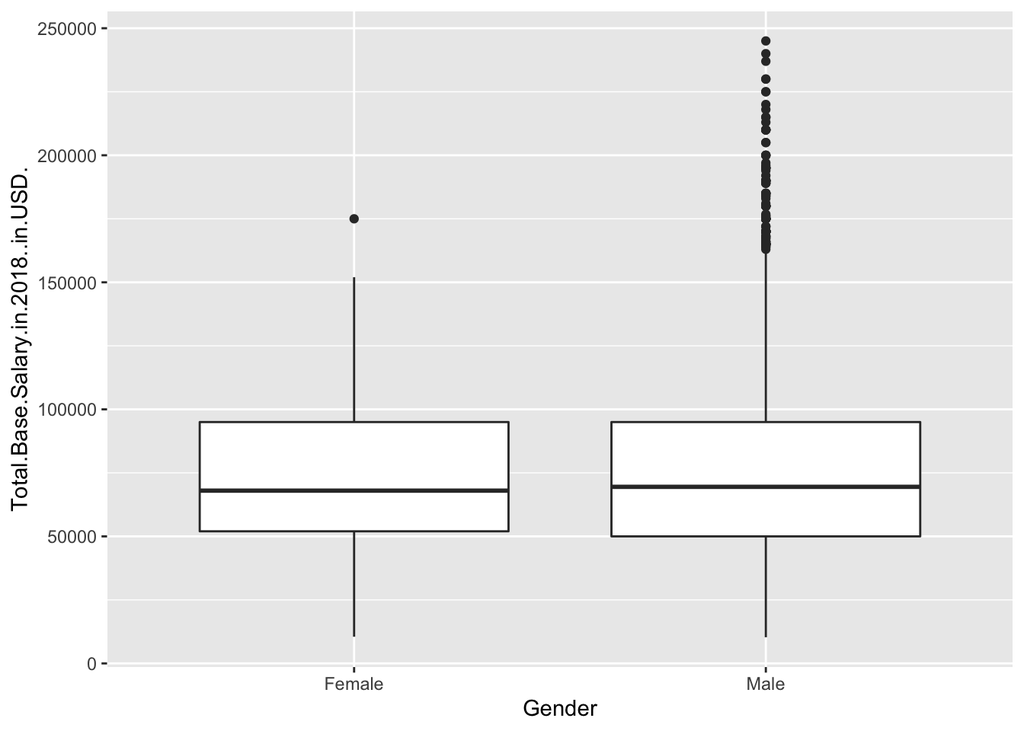

Our second boxplot dispalys distribution based on education level for our Reddit Tech Dataset.

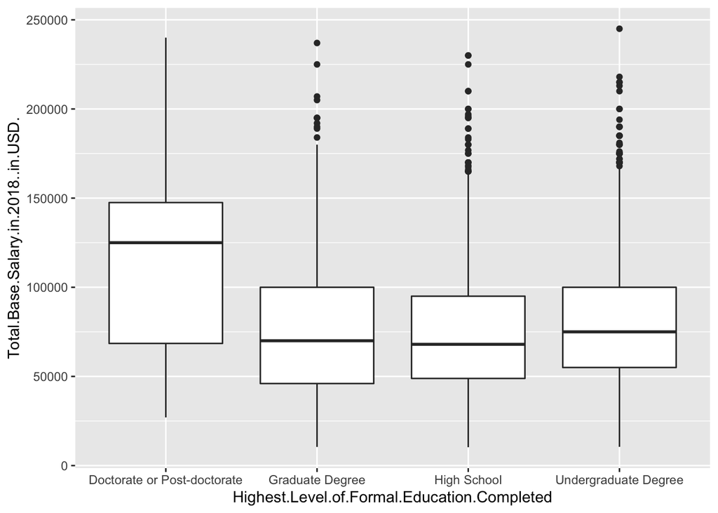

Our final boxplot displays distribution based on mean net wealth per person for our Individual Wealth Dataset.

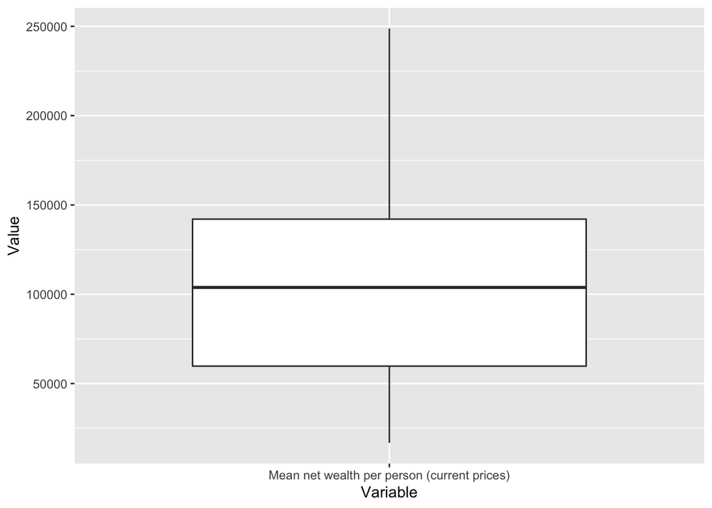

#### Question 3. Significant Outliers Explanation and Analysis

In our datasets, the significant outliers we had was with our salaries. For both datasets, we had some salaries that were over one million dollars! We noticed that this data skewed our boxplots and decided to wrangle each dataframe to only include salaries that were less than 250,000 dollars. In the above boxplots, you can see how there are still some outliers close to the 250,000 dollar mark. Before eliminating all salaries above 250,000 dollars, there were far more outliers that made the actual box part of the plot nonexistant. Ultimately, choosing to wrangle our dataset made our boxplots actually readable in addition to making our future analysis more accurate. Additionally, for our tech salaries dataset, some of the salaries were not inputted. This was skewing our boxplots to have a minimum value of zero so we decided to wrangle this data set to only include salaries that were great than 10,000 dollars and to not include missing values.

Another thing we experienced was for our tech salaries dataset, there were a lot of different types of education listed. We decided to only use the most common types of education and focus on recieving a High School Diploma, Bachelor’s Degree, Master’s Degree, or Doctorate..

The final thing worth mentioning for our tech salaries dataset was that of the over 4,000 reported salaries, only 167 were reported by females. Not only is this a stark representation of the lack of women in the technology industry, it means that some of our analysis done on women may be inaccurate because of the small amount of data we have to go on. Additionally, wre had some outlier genders and decided to wrangle our dataset to only include people who identified as male or female.

## Section 3: Specific Question Analyses

### Kaamna: What is the difference between net income of an average person in the United States compared to a woman working for a Technology company in the U.S.?

#### Question One

My data science question is one that will understand information from both of the data sets we have acquired. We are looking for the difference in mean net income from both of the data sets in specific location of the United States. What is specific to the Reddit data is that we are looking for a specific gender, women, and a specific technology company, Microsoft, to be specific in our data to better understand the wages of a minority gender in a booming field of inequality compared to the average salary of an American.

#### Question Three

```
##          Country                                    Variable       Population
## 1: United States Mean net wealth per person (current prices) Total Population
## 2: United States Mean net wealth per person (current prices) Total Population
## 3: United States Mean net wealth per person (current prices) Total Population
## 4: United States Mean net wealth per person (current prices) Total Population
## 5: United States Mean net wealth per person (current prices) Total Population
## 6: United States Mean net wealth per person (current prices) Total Population
##        Value
## 1: 174855.67
## 2: 189572.23
## 3: 248811.61
## 4: 174855.67
## 5: 189572.23
## 6: 248811.61
```

```
##    Company.Name Primary.Location..Country. Primary.Location..City.
## 1:    Microsoft         United States (US)       Dallas - Ft Worth
## 2:    Microsoft         United States (US)             Redmond, WA
## 3:    Microsoft         United States (US)     Redmond, Washington
##    Highest.Level.of.Formal.Education.Completed
## 1:                        Undergraduate Degree
## 2:                 Doctorate or Post-doctorate
## 3:                        Undergraduate Degree
##    Total.Base.Salary.in.2018..in.USD.
## 1:                              89500
## 2:                             152000
## 3:                             111000
```

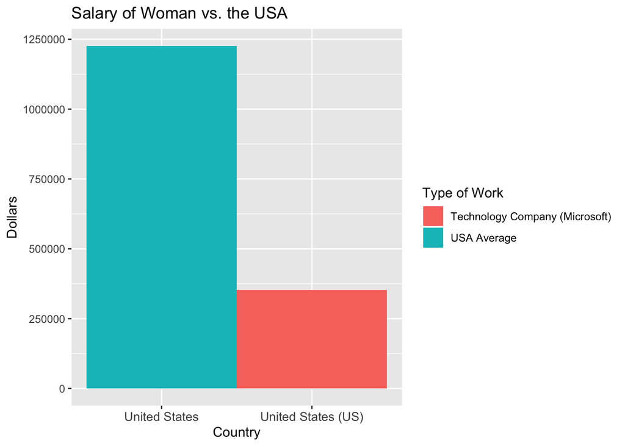

#### Question 2 - Data Analysis Method

My data analysis method began with seperating the salaries of men and women into respective datesets for comparison. Before making a comparison between the wages for both genders, I calculated the mean salary for males and females respectivly. This allowed for immediate comparision between the global average salary of men and women working in the technology industry.

#### Question 3 - Results of Analysis

I created this table to represent the quantitiave results of my data analysis. The table represents how I specifically collected the average salary for men and women.

[output not shown]

I used the above table to guide me on creating the qualititative results of my data analysis. My bar graph compares the average salary of males and females.

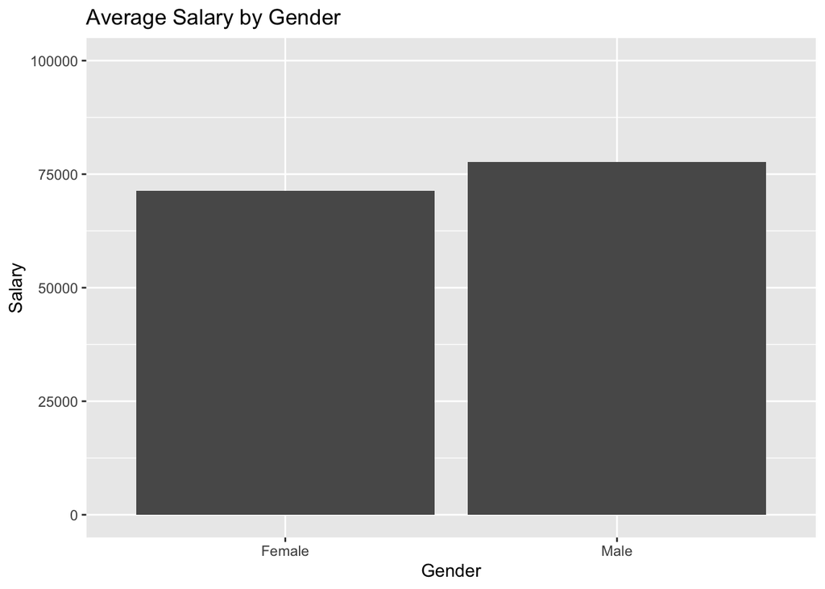

[figure not shown]

### Locksley: Does education level affect the average compensation between different genders?

#### Question 2 - Data Analysis Method

My data analysis method involved taking the average salary for men and women of different education levels and comparing them. In order to do this, I first had to create a new dataframe that included the average salary for men and women for a High School Diploma, Bachelor’s Degree, Master’s Degree, and Doctorate. At this point, I created a scatterplot that represented the means for each of these education levels. Although I would have preferred to be more gender neutral, I decided it would be the most intuitive if I made the male averages blue and the female averages red in my scatterplot.

#### Question 3 - Results of Analysis

I created the below table to represent the quantitiave results of my data analysis. The below table represents how I specifically collected the average salary for men and women that graduated with different degrees.

| Gender | High School Diploma | Bachelor’s Degree | Master’s Degree | Doctorate |  |
| --- | --- | --- | --- | --- | --- |
| Male | 75256 | 81280 | 75826 | 111570 |  |
| Female | 65119 | 77830 | 78086 | 121000 |  |

I used the above table to guide me on creating the qualititative results of my data analysis. My scatter plot compares male and female salaries based on their education level.

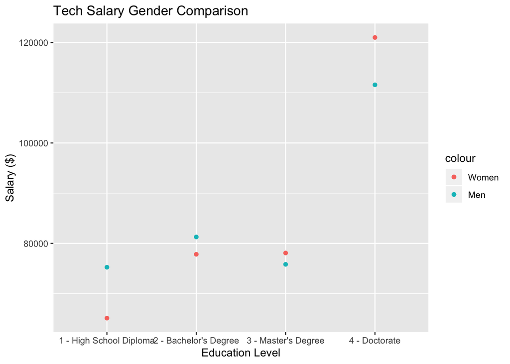

#### Question 4 - Result Evaluation

Overall, my plot indicates that a higher education results in a higher salary, thje primary exception for this being earning a Master’s Degree for men. Unlike women who see an average increase of 256 dollars a year, men are seeing an average decrease of 5,454 dollars for obtaining a Master’s degree. This is especially interesting because in a time when undergraduate degrees are worth less, it is fairly common to pursue a Master’s Degree. Is it possible that people in the tech industry should not waste time and/or money pursuing a degree that produces a very little increase (or decrease) in their salary?

A second observation I made is that it seems very benefical to pursue a Doctorate. For example, men with a Doctorate earn on average 30,290 dollars more than men with a Bachelor’s degree and women with a Doctorate earn on average 43,170 dollars more than women with a Bachelor’s degree. This is especially interesting because it is stereotypically believed that most people with a Doctorate earn less because they are working in Acadamia. I think more research needs to be done with more inputted salaries for people with Doctorates before a conclusion can be drawn.

A final observation I made is men earn more on average who have completed their High School Diploma or Bachelor’s Degree but women earn more who have completed their Master’s or Doctorate Degree. In our data, we see that men who have completed their High School Diploma earn 10,137 dollars more than females and, men who have completed their Bachelor’s Degree earn on average 3,450 dollars more than Females. However, women who have completed their Master’s Degree earn on average 2,260 dollars more than men, and women who have earned their Doctorate earn on average 9,430 dollars more than men. Once again, I think more research needs to be done to include more women in the dataset before a conclusion can be drawn.